# Bayesian GLMM Part4

Author

Murray Logan

Published

21/08/2026

# 1 Preparations

Load the necessary libraries

```r
library(tidyverse) #for data wrangling
library(car)       #for regression diagnostics
library(broom)     #for tidy output
#library(ggfortify) #for model diagnostics
library(knitr)     #for kable
library(emmeans)   #for estimating marginal means
library(MASS)      #for glm.nb
library(brms)
library(broom.mixed)
library(tidybayes)
library(bayesplot)
library(standist)   #for visualizing distributions
library(cmdstanr)   #for cmdstan
library(ggeffects)
library(rstan)
library(DHARMa)
library(ggridges)
library(easystats)     #framework for stats, modelling and visualisation
library(patchwork)
source('helperFunctions.R')
```

# 2 Scenario

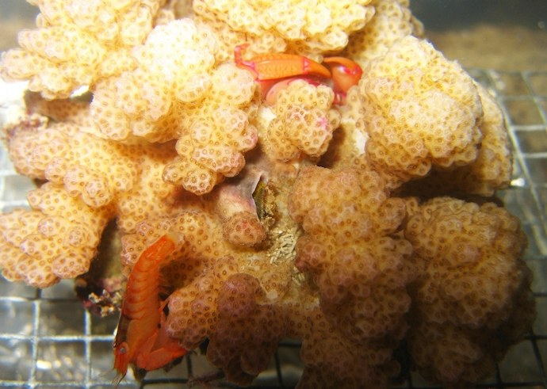

**Figure** 1: Crab_shrimp_coral

To investigate synergistic coral defence by mutualist crustaceans, Mckeon et al. (2012) conducted an aquaria experiment in which colonies of a coral species were placed in a tank along with a predatory sea star and one of four symbiont combinations:

- no symbiont,
- a crab symbiont
- a shrimp symbiont
- both a crab and shrimp symbiont.

The experiments were conducted in a large octagonal flow-through seawater tank that was partitioned into eight sections, which thereby permitted two of each of the four symbiont combinations to be observed concurrently. The tank was left overnight and in the morning, the presence of feeding scars on each coral colony was scored as evidence of predation. The experiments were repeated ten times, each time with fresh coral colonies, sea stars and symbiont.

The ten experimental times represent blocks (random effects) within which the symbiont type (fixed effect) are nested.

# 3 Read in the data

```r
mckeon <- read_csv("../data/mckeon.csv", trim_ws = TRUE)
head(mckeon)
```

```
# A tibble: 6 × 3
  BLOCK PREDATION SYMBIONT
  <dbl>     <dbl> <chr>
1     1         0 none
2     1         1 none
3     2         1 none
4     2         1 none
5     3         1 none
6     3         1 none
```

```r
#block is random effect
#symbint is within block (random slopes could be an option)
#predation is response (binary so we use Bernouli with logit link function)

#set factor levels and make the control (none) first
mckeon <- mckeon |>
  mutate(BLOCK = factor(BLOCK),
         SYMBIONT = factor(SYMBIONT, levels = c('none', 'crabs', 'shrimp', 'both')))
```

# 4 Exploratory data analysis

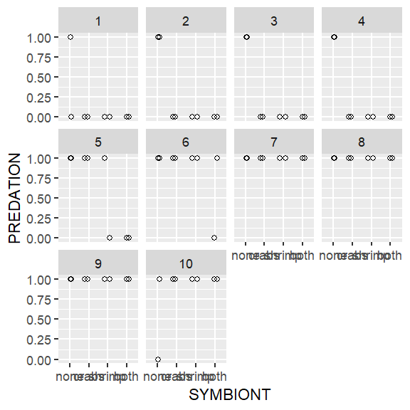

```r
#symbiont x-axis
#predation y-axis
#facet by blocks

mckeon |>
  ggplot(aes(y = PREDATION, x = SYMBIONT)) +
  geom_point(position = position_jitter(width = 0.2, height = 0), shape = 21) +
  facet_wrap(~BLOCK)
```

```r
#might want to consider random slope model because the response is different for different corals
```

Random intercept/slope model formula:
$$\begin{align}
y_i &\sim{} \mathcal{N}(n, p_i)\\
ln\left(\frac{p_i}{1-p_1}\right) &=\boldsymbol{\beta} \bf{X_i} + \boldsymbol{\gamma} \bf{Z_i}\\
\beta_0 &\sim{} \mathcal{N}(0, 2)\\
\beta_1 &\sim{} \mathcal{N}(0, 10)\\
\boldsymbol{\gamma_j} &\sim{} \mathcal{N}(0, \boldsymbol{\Sigma})\\
\boldsymbol{\Sigma} &= \boldsymbol{D}({\sigma_b^2})\boldsymbol{\Omega}\boldsymbol{D}({\sigma_b^2})\\
\boldsymbol{\Omega} &\sim{} LKJ(\zeta)\\
\sigma_b^2 &\sim{} \mathcal{t}(3,0,1.5)\\
\end{align}$$

where $\boldsymbol{\beta}$ and $\boldsymbol{\gamma}$ are vectors of the fixed and random effects parameters respectively and $\bf{X}$ is the model matrix representing the overall intercept and effects of symbionts on the probability of the colony experiencing predation. $\bf{Z}$ represents a cell means model matrix for the random intercepts associated with individual coral colonies.

# 5 Fit the model

```r
mckeon_form <- bf(PREDATION ~ (1|BLOCK) + SYMBIONT,
                  family = bernoulli(link = "logit"))
```

```r
get_prior(mckeon_form, data = mckeon)
```

```
                prior     class           coef group resp dpar nlpar lb ub tag
               (flat)         b
               (flat)         b   SYMBIONTboth
               (flat)         b  SYMBIONTcrabs
               (flat)         b SYMBIONTshrimp
 student_t(3, 0, 2.5) Intercept
 student_t(3, 0, 2.5)        sd                                       0
 student_t(3, 0, 2.5)        sd                BLOCK                  0
 student_t(3, 0, 2.5)        sd      Intercept BLOCK                  0
       source
      default
 (vectorized)
 (vectorized)
 (vectorized)
      default
      default
 (vectorized)
 (vectorized)
```

```r
priors <- prior(normal(0, 2), class = 'Intercept') + #predation for "none" group
  prior(normal(0, 5), class = 'b') + #on logit scale you have a range of -3 to 3 ALWYAS, the mean is 0, and variance you need to be able to move quite a way so needs to be like 3-5
  prior(student_t(3, 0, 2), class='sd') #how variable is the "none" group across blocks?
```

```r
mckeon_brm2 <- brm(mckeon_form,
                 data=mckeon,
                 prior=priors,
                 sample_prior="only",
                 iter=5000,
                 chains=3, cores=3, #one core per chain
                 warmup=1000,
                 thin=5,
                 backend="cmdstanr",
                 refresh=0,
                 seed = 1,
                 control = list(adapt_delta = 0.99))
```

```
Running MCMC with 3 parallel chains...

Chain 1 finished in 0.2 seconds.
Chain 2 finished in 0.2 seconds.
Chain 3 finished in 0.2 seconds.

All 3 chains finished successfully.
Mean chain execution time: 0.2 seconds.
Total execution time: 0.4 seconds.
```

```r
mckeon_brm3 <- update(mckeon_brm2, sample_prior = 'yes',
                      refresh = 0)
```

```
The desired updates require recompiling the model
```

```
Running MCMC with 3 sequential chains...

Chain 1 finished in 1.5 seconds.
Chain 2 finished in 1.7 seconds.
Chain 3 finished in 1.3 seconds.

All 3 chains finished successfully.
Mean chain execution time: 1.5 seconds.
Total execution time: 4.8 seconds.
```

```
Ignoring unknown labels:
• fill : "NA"
• colour : "NA"
Ignoring unknown labels:
• fill : "NA"
• colour : "NA"
```

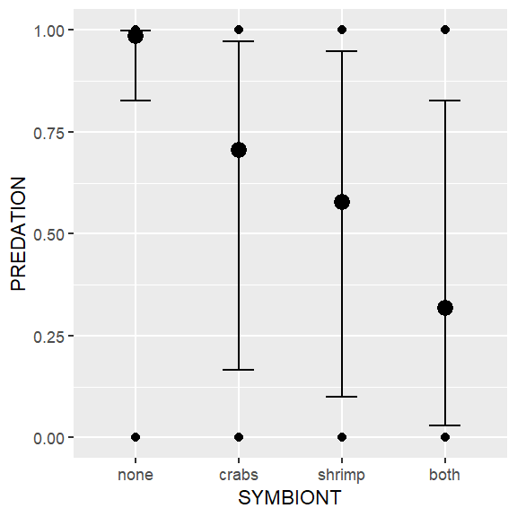

```r
mckeon_brm3 |>
  conditional_effects() |>
  plot(points = TRUE)
```

```r
#need to remember these are distributions!!! So mass is not equally distributed along the vertical lines, it is denser in the center by the mean
```